In this analysis, I will apply tree-based methods (Decision Trees, Bagging, Random Forest, and GBM) to the heart disease classification problem.

### Data Preparation

We will use the same **Heart** data, available at http://www-bcf.usc.edu/~gareth/ISL/Heart.csv.

```r
heart <- read.csv(file="http://www-bcf.usc.edu/~gareth/ISL/Heart.csv", row.names=1)
summary(heart)
```

```
##       Age             Sex                ChestPain       RestBP           Chol            Fbs            RestECG
##  Min.   :29.00   Min.   :0.0000   asymptomatic:144   Min.   : 94.0   Min.   :126.0   Min.   :0.0000   Min.   :0.0000
##  1st Qu.:48.00   1st Qu.:0.0000   nonanginal  : 86   1st Qu.:120.0   1st Qu.:211.0   1st Qu.:0.0000   1st Qu.:0.0000
##  Median :56.00   Median :1.0000   nontypical  : 50   Median :130.0   Median :241.0   Median :0.0000   Median :1.0000
##  Mean   :54.44   Mean   :0.6799   typical     : 23   Mean   :131.7   Mean   :246.7   Mean   :0.1485   Mean   :0.9901
##  3rd Qu.:61.00   3rd Qu.:1.0000                      3rd Qu.:140.0   3rd Qu.:275.0   3rd Qu.:0.0000   3rd Qu.:2.0000
##  Max.   :77.00   Max.   :1.0000                      Max.   :200.0   Max.   :564.0   Max.   :1.0000   Max.   :2.0000
##
##      MaxHR           ExAng           Oldpeak         Slope             Ca                 Thal      AHD
##  Min.   : 71.0   Min.   :0.0000   Min.   :0.00   Min.   :1.000   Min.   :0.0000   fixed     : 18   No :164
##  1st Qu.:133.5   1st Qu.:0.0000   1st Qu.:0.00   1st Qu.:1.000   1st Qu.:0.0000   normal    :166   Yes:139
##  Median :153.0   Median :0.0000   Median :0.80   Median :2.000   Median :0.0000   reversable:117
##  Mean   :149.6   Mean   :0.3267   Mean   :1.04   Mean   :1.601   Mean   :0.6722   NA's      :  2
##  3rd Qu.:166.0   3rd Qu.:1.0000   3rd Qu.:1.60   3rd Qu.:2.000   3rd Qu.:1.0000
##  Max.   :202.0   Max.   :1.0000   Max.   :6.20   Max.   :3.000   Max.   :3.0000
##                                                                  NA's   :4
```

The task is to use the features to predict **AHD**, binary outcome related to some heart disease.

Some cleaning is necessary because there are NA’s and also several categorical variables stored as numerical.

```r
# clean the NA's
heart <- na.omit(heart)
# convert to factors
heart$Sex <- as.factor(heart$Sex)
heart$Fbs <- as.factor(heart$Fbs)
heart$RestECG <- as.factor(heart$RestECG)
heart$ExAng <- as.factor(heart$ExAng)
heart$Slope <- as.factor(heart$Slope)
heart$Ca <- as.factor(heart$Ca)
summary(heart)
```

```
##       Age        Sex            ChestPain       RestBP           Chol       Fbs     RestECG     MaxHR       ExAng
##  Min.   :29.00   0: 96   asymptomatic:142   Min.   : 94.0   Min.   :126.0   0:254   0:147   Min.   : 71.0   0:200
##  1st Qu.:48.00   1:201   nonanginal  : 83   1st Qu.:120.0   1st Qu.:211.0   1: 43   1:  4   1st Qu.:133.0   1: 97
##  Median :56.00           nontypical  : 49   Median :130.0   Median :243.0           2:146   Median :153.0
##  Mean   :54.54           typical     : 23   Mean   :131.7   Mean   :247.4                   Mean   :149.6
##  3rd Qu.:61.00                              3rd Qu.:140.0   3rd Qu.:276.0                   3rd Qu.:166.0
##  Max.   :77.00                              Max.   :200.0   Max.   :564.0                   Max.   :202.0
##     Oldpeak      Slope   Ca              Thal      AHD
##  Min.   :0.000   1:139   0:174   fixed     : 18   No :160
##  1st Qu.:0.000   2:137   1: 65   normal    :164   Yes:137
##  Median :0.800   3: 21   2: 38   reversable:115
##  Mean   :1.056           3: 20
##  3rd Qu.:1.600
##  Max.   :6.200
```

Next, we will prepare the training and test dataset for later model comparison.

```r
# split training and test data 50/50
N <- nrow(heart)
set.seed(456)
train.index <- sample(1:N, round(N/2))
test.index <- - train.index
```

Let’s separate the test data for GBM use.

```r
x.test <- heart[test.index, 1:13]
y.test <- heart[test.index, 14]
```

### Decision Trees as a benchmark.

Fit the optimal Decision Tree model using the training data (including growing, cross-validation tree size, and pruning), and use the model to predict the probability of AHD using the test data.

```r
library("tree")

# grow a tree
heart.tree <- tree(AHD ~ ., data=heart, subset=train.index)

# pruning by cross-validation
set.seed(123) #as it is a categorical outcome, in tree making we change the method to misclass
heart.tree.cv <- cv.tree(heart.tree, method="misclass")

# optimal tree size obtained by CV
optimal <- which.min(heart.tree.cv$dev)
optimal.size <- heart.tree.cv$size[optimal]

# pruned tree
heart.tree.pruned <- prune.tree(heart.tree, best=optimal.size, method="misclass")
heart.tree.pruned
```

```
## node), split, n, deviance, yval, (yprob)
##       * denotes terminal node
##
##  1) root 148 205.100 No ( 0.50676 0.49324 )
##    2) Thal: normal 76  80.790 No ( 0.77632 0.22368 )
##      4) Age < 54.5 39   9.301 No ( 0.97436 0.02564 ) *
##      5) Age > 54.5 37  50.620 No ( 0.56757 0.43243 )
##       10) Oldpeak < 2.2 32  41.180 No ( 0.65625 0.34375 ) *
##       11) Oldpeak > 2.2 5   0.000 Yes ( 0.00000 1.00000 ) *
##    3) Thal: fixed,reversable 72  76.280 Yes ( 0.22222 0.77778 )
##      6) Oldpeak < 0.7 18  24.060 No ( 0.61111 0.38889 )
##       12) Chol < 228 11  10.430 No ( 0.81818 0.18182 ) *
##       13) Chol > 228 7   8.376 Yes ( 0.28571 0.71429 ) *
##      7) Oldpeak > 0.7 54  33.320 Yes ( 0.09259 0.90741 ) *
```

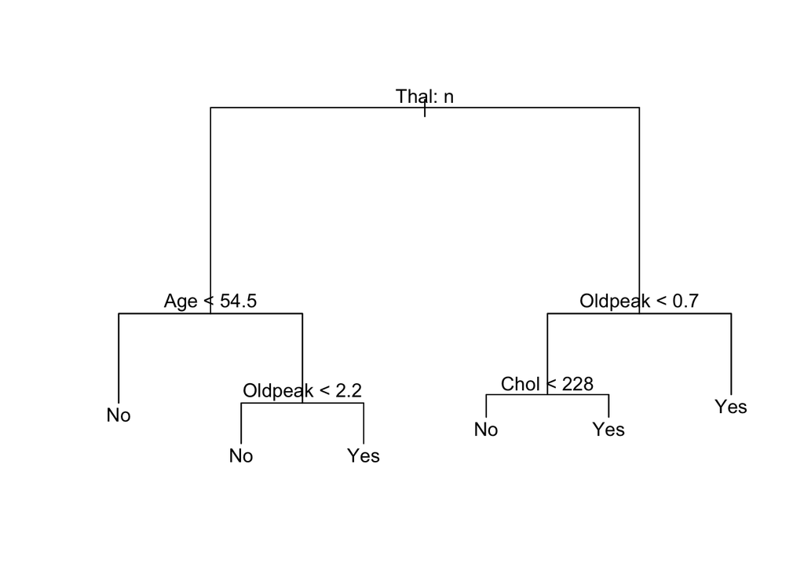

```r
plot(heart.tree.pruned)
text(heart.tree.pruned, pretty=TRUE)
```

```r
# prediction on test data ##RK: while predicting for categorical data, output has 2 columns- 1st one p(No) & 2nd : prob (Yes)
prob.tree <- predict(heart.tree.pruned, newdata=heart[test.index, ], type="vector")[, 2]

# misclassification error in test data
pred.tree <- predict(heart.tree.pruned, newdata=heart[test.index, ], type="class")
table(pred.tree, y.test)
```

```
##          y.test
## pred.tree No Yes
##       No  71  20
##       Yes 14  44
```

### Q1. Bagging.

Fit a Bagging model with 501 trees on the training data, and predict the probability of AHD on the test data.

**[REMARK]**: In binay classification, we often use an odd number of trees in order to break tie in the vote.

```r
library("randomForest")
heart.bag <- randomForest(AHD ~ ., data=heart, subset=train.index, mtry=13, ntree=501, na.action=na.fail)

heart.bag
```

```
##
## Call:
##  randomForest(formula = AHD ~ ., data = heart, mtry = 13, ntree = 501,      subset = train.index, na.action = na.fail)
##                Type of random forest: classification
##                      Number of trees: 501
## No. of variables tried at each split: 13
##
##         OOB estimate of  error rate: 22.3%
## Confusion matrix:
##     No Yes class.error
## No  60  15   0.2000000
## Yes 18  55   0.2465753
```

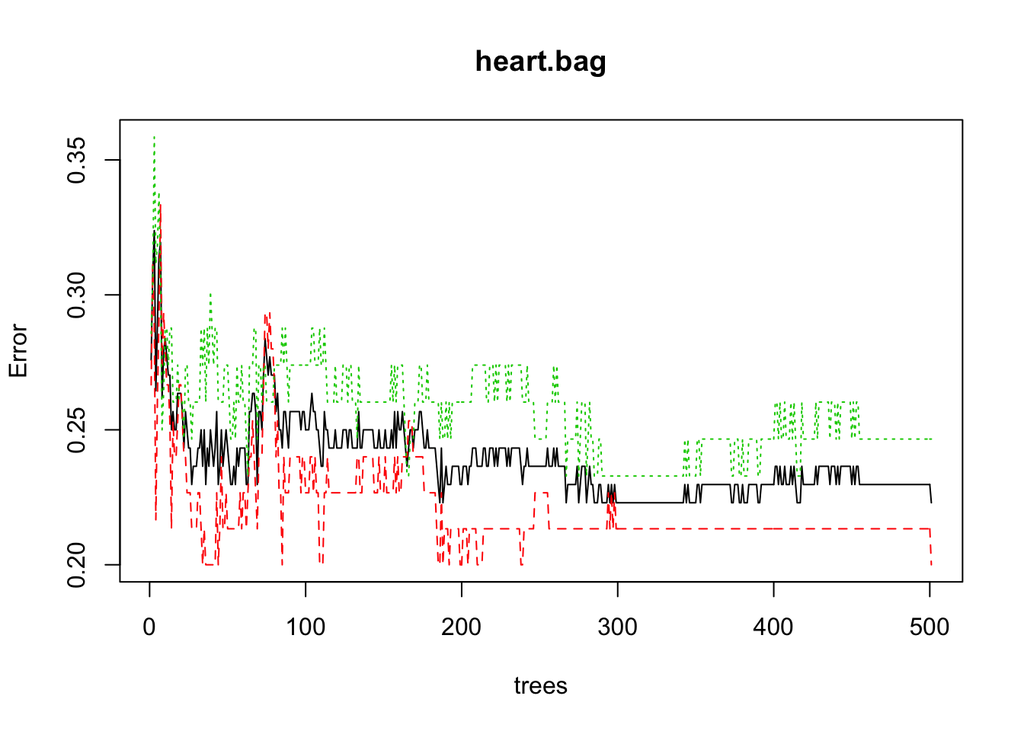

```r
plot(heart.bag)
```

```r
# predict
yhat.bag <- predict(heart.bag, newdata=x.test, type="prob")
```

### Q2. Random Forest.

1. Fit a Random Forest model with 501 trees on the training data (remember to optimize **mtry**), and predict the probability of AHD on the test data.

```r
library("randomForest")
tuneRF(x=heart[train.index, -14], y=heart[train.index, 14], mtryStart=2, ntreeTry=501, stepFactor=1.5)
```

```
## mtry = 2  OOB error = 17.57%
## Searching left ...
## Searching right ...
## mtry = 3     OOB error = 17.57%
## 0 0.05
```

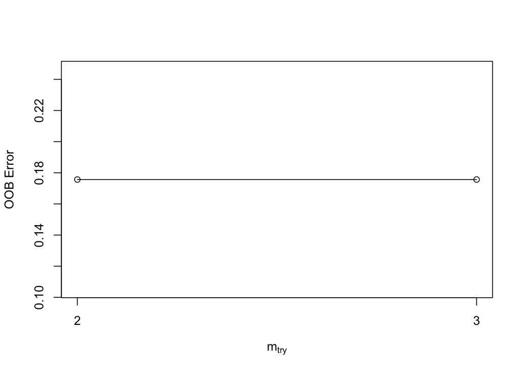

```
##       mtry  OOBError
## 2.OOB    2 0.1756757
## 3.OOB    3 0.1756757
```

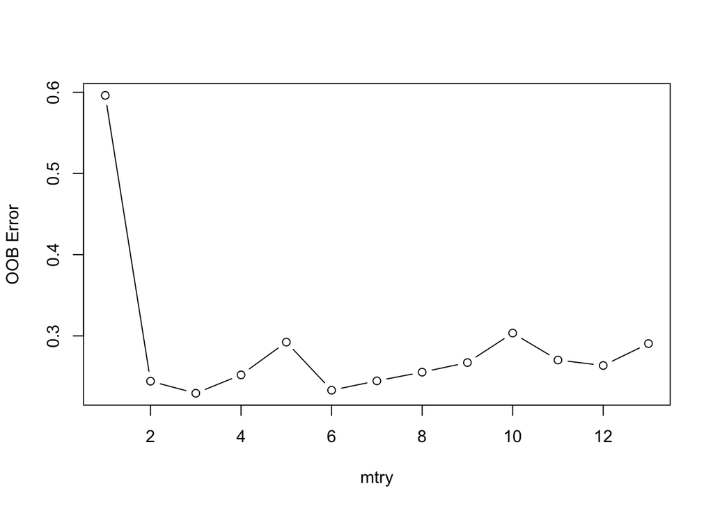

```r
#as tuneRF is giving very unstable output, we further tried to tune manually.
#tuning manually

# evaluating optimal number of predictors *mtry*
miscal.rfs <- rep(0, 13)
for(m in 1:13) {
    set.seed(12)
    rf <- randomForest(AHD ~ ., data=heart, subset=train.index, mtry=m, ntree=501, importance=TRUE)
    miscal.rfs[m] <- rf$err.rate[m,"OOB"]
  }

plot(1:13, miscal.rfs, type="b", xlab="mtry", ylab="OOB Error")
```

```r
optm.rf<- which.min(miscal.rfs)

#optimal model
heart.rf<- randomForest(AHD ~ ., data=heart, subset=train.index, mtry=optm.rf, ntree=501, importance=TRUE)

#predicting for the test data
yhat.RF <- predict(heart.rf, newdata=x.test, type="prob")
```

2. Plot the variable importance and find out how having AHD is related to variables “MaxHR” and “Thal.” Briefly interpret the plots.

```r
importance(heart.rf)
```

```
##                   No       Yes MeanDecreaseAccuracy MeanDecreaseGini
## Age        6.2122466  5.462904             8.284172        6.4130494
## Sex        7.5951435 -1.572271             4.284479        1.5253070
## ChestPain  4.2608053  6.293348             7.330613        5.8565376
## RestBP     0.4834164  4.410300             3.173015        5.8914224
## Chol       4.4328299 -3.049805             1.493566        5.7406271
## Fbs        3.3485971 -2.244822             1.733990        0.6313662
## RestECG    2.4557776  1.104832             2.525670        1.5307923
## MaxHR      9.1685035 10.838522            13.633855       10.3056499
## ExAng      4.6157834  5.675214             6.967430        2.7924913
## Oldpeak   10.2234968 11.406436            15.185133       10.5534610
## Slope      4.7879505 10.197911            10.565966        4.9511808
## Ca        16.4834907  9.164913            16.786842        6.8124639
## Thal      14.2480089 12.672716            17.255113        9.8288348
```

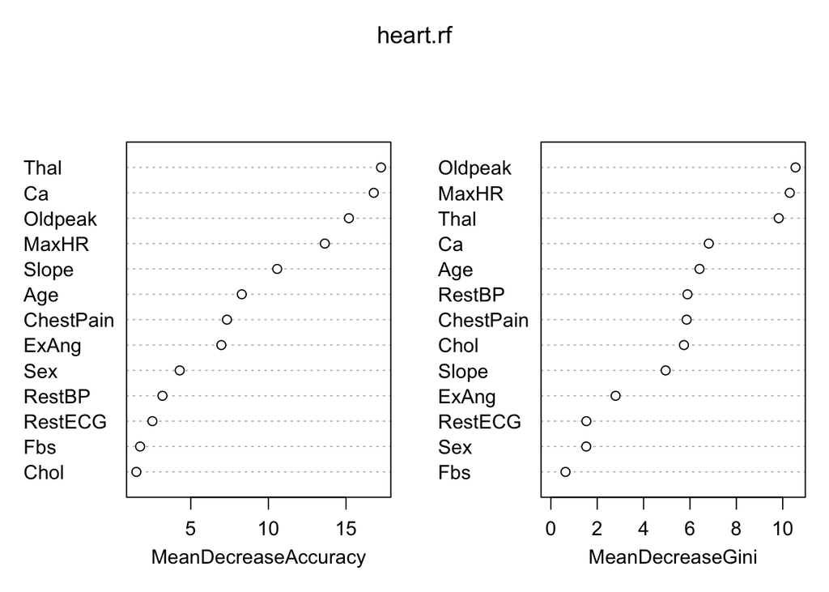

```r
varImpPlot(heart.rf)
```

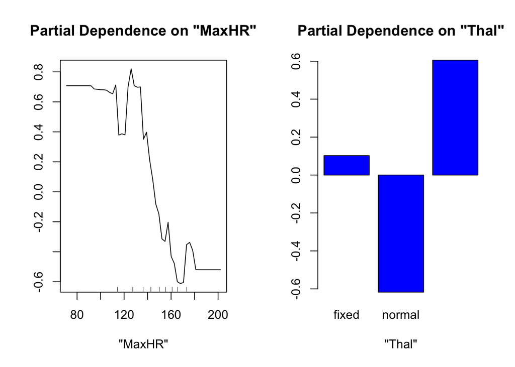

```r
par(mfrow=c(1,2))
partialPlot(heart.rf, heart[train.index, ], x.var="MaxHR", which.class = "Yes")
partialPlot(heart.rf, heart[train.index, ], x.var="Thal",which.class = "Yes")
```

```r
par(mfrow=c(1,1))
```

For MaxHR, the values greater than 140 have highler influence on accurately predicting the classification.

### Q3. Gradient Boosting Machines.

1. Fit a GBM model on the training data, try your best to find the optimal **n.trees**, **shrinkage**, and **interaction.depth** using cross-validtion, and predict the probability of AHD on the test data.

```r
#GBM Model
library("gbm")
set.seed(123)

heart1 <- heart
heart1$AHD1 <- ifelse(heart1$AHD =="Yes",1,0)
heart1$AHD1 <- as.numeric(heart1$AHD1)
heart1$AHD <- NULL
ygbm.test <- heart[test.index, 15]
summary(heart1)
```

```
##       Age        Sex            ChestPain       RestBP           Chol       Fbs     RestECG     MaxHR       ExAng
##  Min.   :29.00   0: 96   asymptomatic:142   Min.   : 94.0   Min.   :126.0   0:254   0:147   Min.   : 71.0   0:200
##  1st Qu.:48.00   1:201   nonanginal  : 83   1st Qu.:120.0   1st Qu.:211.0   1: 43   1:  4   1st Qu.:133.0   1: 97
##  Median :56.00           nontypical  : 49   Median :130.0   Median :243.0           2:146   Median :153.0
##  Mean   :54.54           typical     : 23   Mean   :131.7   Mean   :247.4                   Mean   :149.6
##  3rd Qu.:61.00                              3rd Qu.:140.0   3rd Qu.:276.0                   3rd Qu.:166.0
##  Max.   :77.00                              Max.   :200.0   Max.   :564.0                   Max.   :202.0
##     Oldpeak      Slope   Ca              Thal          AHD1
##  Min.   :0.000   1:139   0:174   fixed     : 18   Min.   :0.0000
##  1st Qu.:0.000   2:137   1: 65   normal    :164   1st Qu.:0.0000
##  Median :0.800   3: 21   2: 38   reversable:115   Median :0.0000
##  Mean   :1.056           3: 20                    Mean   :0.4613
##  3rd Qu.:1.600                                    3rd Qu.:1.0000
##  Max.   :6.200                                    Max.   :1.0000
```

```r
heart.gbm <- gbm(AHD1~ .,data=heart1[train.index, ],distribution="bernoulli", n.trees=5000, interaction.depth=4,shrinkage = 0.0001)

gbm.perf(heart.gbm)
```

```
## Using OOB method...
```

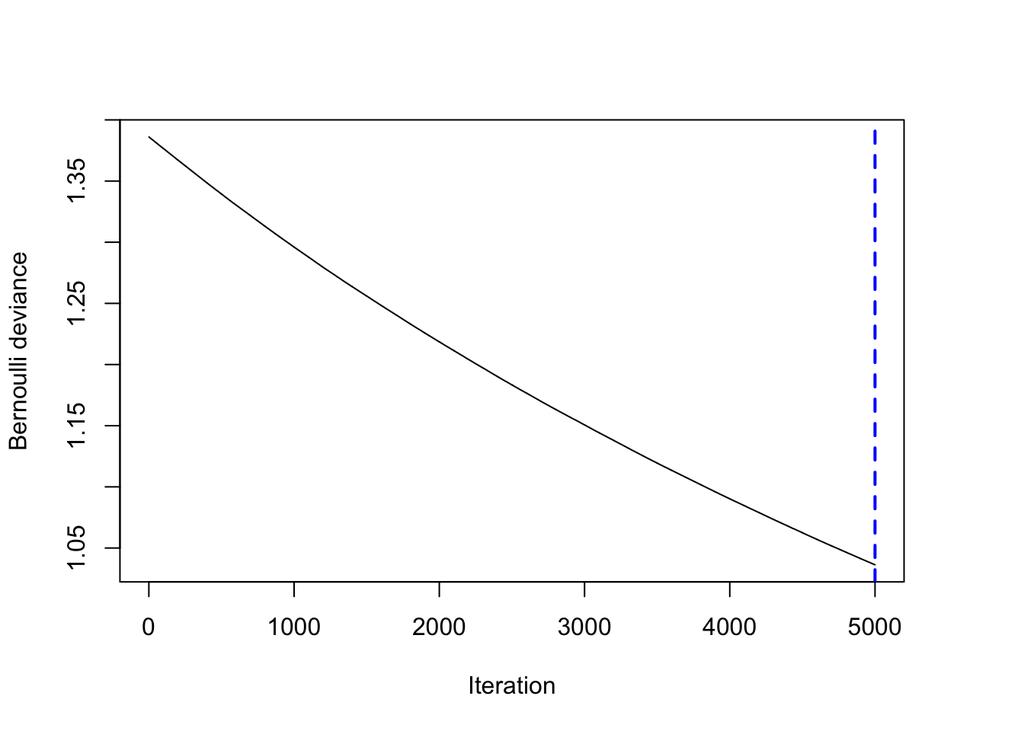

```
## [1] 5000
```

```r
# predict
heart.gbm.predict <- predict(heart.gbm,newdata=heart1[test.index, ],n.trees=5000,type="response")

# inspect a particular tree
pretty.gbm.tree(heart.gbm, i.tree=2)
```

```
##    SplitVar SplitCodePred LeftNode RightNode MissingNode ErrorReduction Weight    Prediction
## 0         7  1.370000e+02        1         5          12     7.37220611     74 -2.702248e-06
## 1         7  1.295000e+02        2         3           4     0.05653785     23  1.853347e-04
## 2        -1  2.027317e-04       -1        -1          -1     0.00000000     13  2.027317e-04
## 3        -1  1.627186e-04       -1        -1          -1     0.00000000     10  1.627186e-04
## 4        -1  1.853347e-04       -1        -1          -1     0.00000000     23  1.853347e-04
## 5        11  3.000000e+00        6        10          11     2.50963701     51 -8.750321e-05
## 6         3  1.280000e+02        7         8           9     0.59605065     34 -1.502577e-04
## 7        -1 -1.973241e-04       -1        -1          -1     0.00000000     19 -1.973241e-04
## 8        -1 -9.064031e-05       -1        -1          -1     0.00000000     15 -9.064031e-05
## 9        -1 -1.502577e-04       -1        -1          -1     0.00000000     34 -1.502577e-04
## 10       -1  3.800586e-05       -1        -1          -1     0.00000000     17  3.800586e-05
## 11       -1 -8.750321e-05       -1        -1          -1     0.00000000     51 -8.750321e-05
## 12       -1 -2.702248e-06       -1        -1          -1     0.00000000     74 -2.702248e-06
```

```r
# Optimal GBM model: tune gbm by CV

#Note to Professor Tong: This is the code to tune the GBM, however as it is taking long time to execute so it has been commented while generating the html file

# n.step <- 50
# ds <- c(1, 2, 4, 6, 8)
# lambdas <- c(0.01, 0.005, 0.001, 0.0005)
# d.size <- length(ds)
# l.size <- length(lambdas)
#
# tune.out <- data.frame()
# for (i in 1:d.size) {
#     for (j in 1:l.size) {
#         d <- ds[i]
#         lambda <- lambdas[j]
#         for (n in (1:10) * n.step / (lambda * sqrt(d))) {
#             set.seed(321)
#             gbm.mod <- gbm(AHDNew ~ ., data=heart[train.index, ], distribution="bernoulli", n.trees=n, interaction.depth=d, shrinkage=lambda, cv.folds=10)
#             n.opt <- gbm.perf(gbm.mod, method="cv")
#             cat("n =", n, " n.opt =", n.opt, "\n")
#             if (n.opt / n < 0.95) break
#         }
#         cv.err <- gbm.mod$cv.error[n.opt]
#         pred <- predict(gbm.mod, newdata=heart[test.index,], n.trees=n.opt)
#         pred2 <- as.integer(ifelse(pred > 0.5, 1, 0))
#         test.err <- sum(pred2!=ygbm.test)/length(ygbm.test)
#         out <- data.frame(d=d, lambda=lambda, n=n, n.opt=n.opt, cv.err=cv.err, test.err=test.err)
#         print(out)
#         tune.out <- rbind(tune.out, out)
#     }
# }

# Tuning Params

#  d lambda    n      n.opt    cv.err
#  5  0.001 22360.68  4117   0.754706

#Optimal GBM model
set.seed(321)
heart.gbm3 <- gbm(AHD1 ~ ., data=heart1[train.index, ], distribution="bernoulli", n.trees=22361, interaction.depth=5, shrinkage=0.001)
heart.gbm3
```

```
## gbm(formula = AHD1 ~ ., distribution = "bernoulli", data = heart1[train.index,
##     ], n.trees = 22361, interaction.depth = 5, shrinkage = 0.001)
## A gradient boosted model with bernoulli loss function.
## 22361 iterations were performed.
## There were 13 predictors of which 13 had non-zero influence.
```

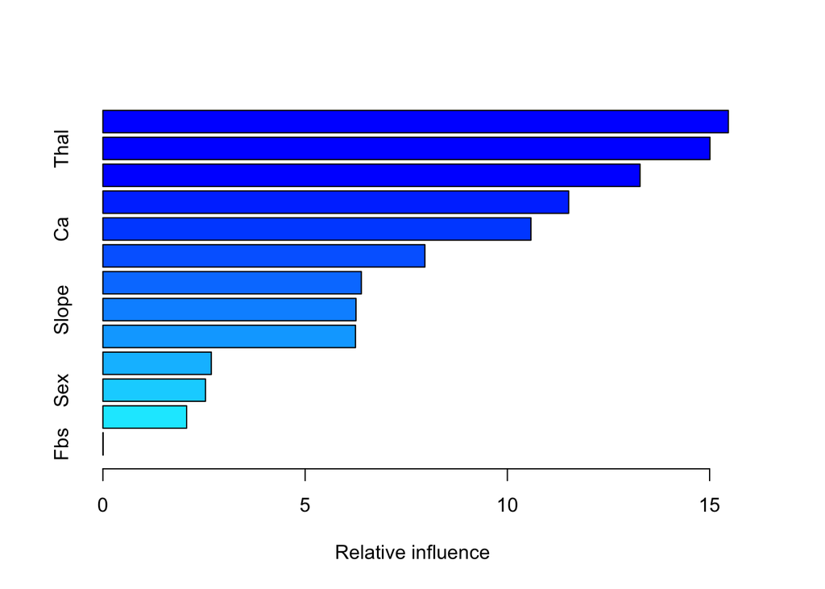

```
##                 var      rel.inf
## MaxHR         MaxHR 15.463833067
## Thal           Thal 15.008923026
## Oldpeak     Oldpeak 13.279941507
## Age             Age 11.516248558
## Ca               Ca 10.582388548
## Chol           Chol  7.961546404
## RestBP       RestBP  6.389752359
## Slope         Slope  6.257482972
## ChestPain ChestPain  6.245387611
## RestECG     RestECG  2.680561859
## Sex             Sex  2.536531282
## ExAng         ExAng  2.070223960
## Fbs             Fbs  0.007178846
```

```r
summary(heart.gbm3)
```

```r
heart.gbm.predict3 <- predict(heart.gbm3, newdata=heart[test.index, ], n.trees=22361,type="response")
```

2. Plot the variable importance, find out the partial dependency on variables “MaxHR”, “Thal”, and the two variables “Age” and “Chol” jointly. Briefly interpret the plots.

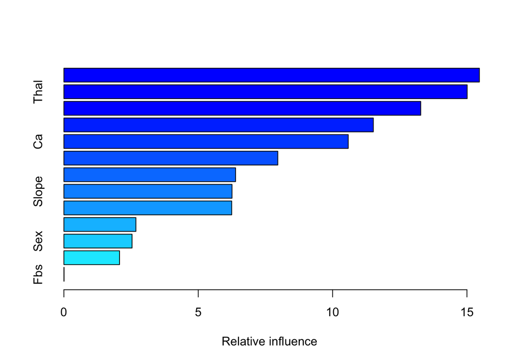

```
##                 var      rel.inf
## MaxHR         MaxHR 15.463833067
## Thal           Thal 15.008923026
## Oldpeak     Oldpeak 13.279941507
## Age             Age 11.516248558
## Ca               Ca 10.582388548
## Chol           Chol  7.961546404
## RestBP       RestBP  6.389752359
## Slope         Slope  6.257482972
## ChestPain ChestPain  6.245387611
## RestECG     RestECG  2.680561859
## Sex             Sex  2.536531282
## ExAng         ExAng  2.070223960
## Fbs             Fbs  0.007178846
```

```r
summary(heart.gbm3)
```

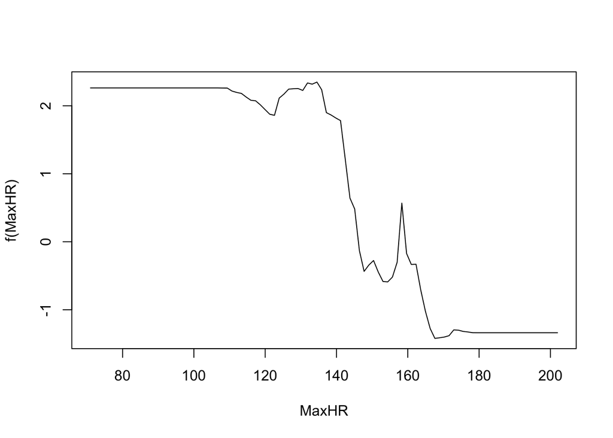

```r
# partial plot in gbm
plot(heart.gbm3, na.rm=TRUE, i="MaxHR")
```

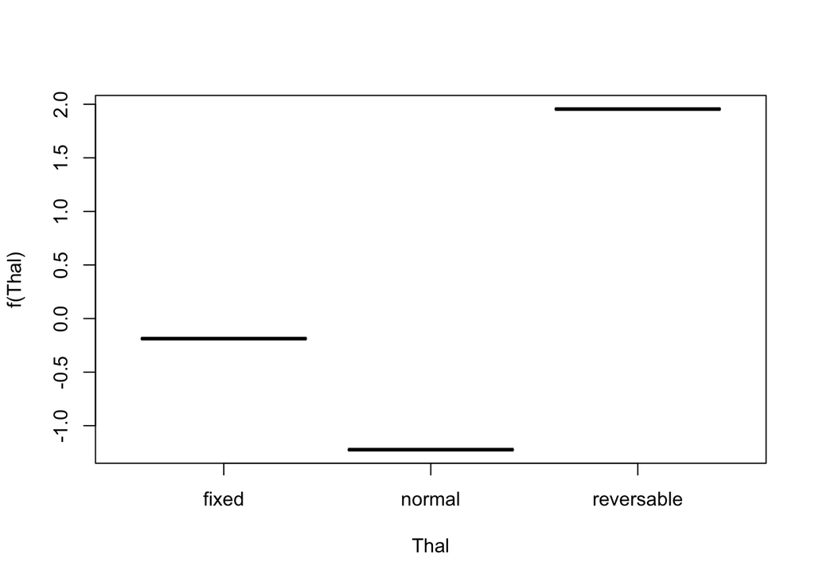

```r
plot(heart.gbm3, i="Thal")
```

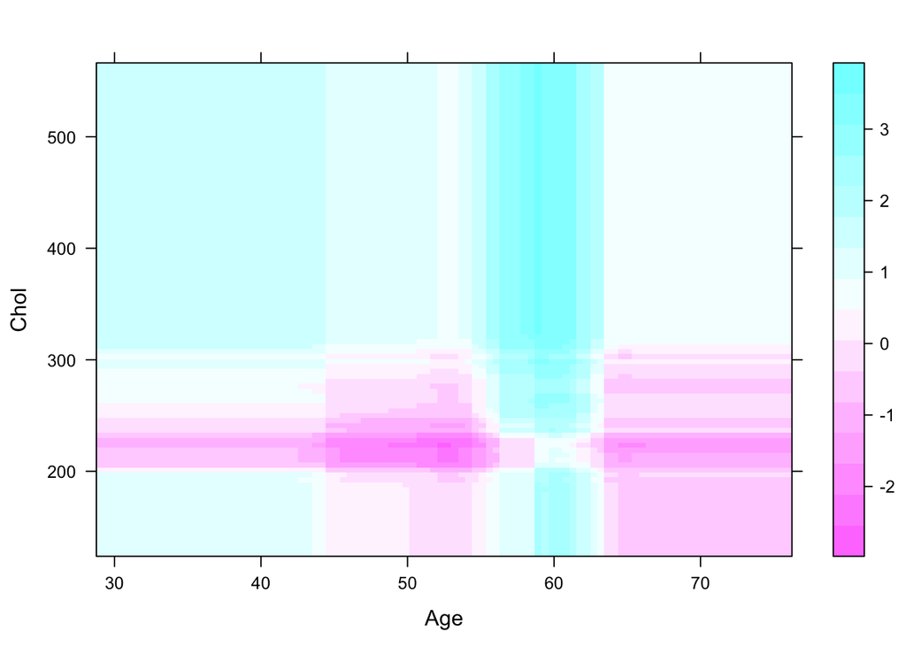

```r
plot(heart.gbm3, i=c("Age", "Chol"))
```

### Q4. Compare the above-studied model predictions in terms of misclassification rate and AUC.

```r
library("ROCR")
```

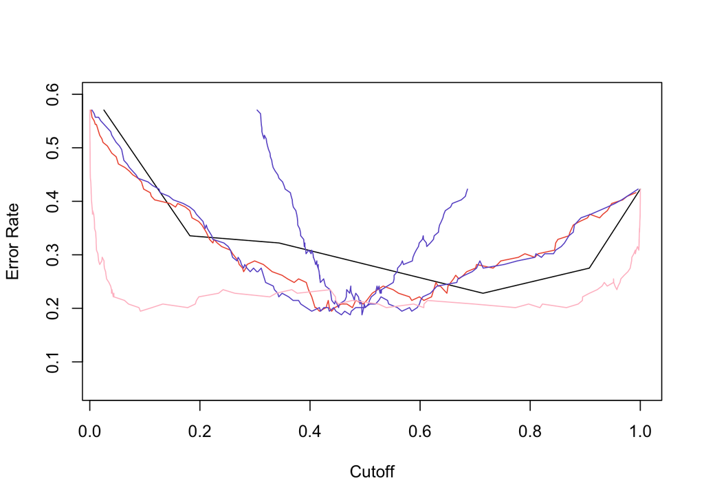

```r
# Misclassification Rate

tree.pred <- prediction(prob.tree,y.test)
bagging.pred <- prediction(yhat.bag[,2],y.test)
rf.pred <- prediction(yhat.RF[,2],y.test)
gbm.pred <- prediction(heart.gbm.predict,y.test)
gbm.pred.tune <- prediction(heart.gbm.predict3,y.test)


tree.err <- performance(tree.pred,measure="err")
bagging.err <- performance(bagging.pred, measure="err")
rf.err <- performance(rf.pred, measure="err")
gbm.err <- performance(gbm.pred, measure="err")
gbm.err.tune <- performance(gbm.pred.tune, measure="err")

plot(tree.err,,ylim=c(0.05,0.6))
plot(bagging.err,col='tomato2',add=T)
plot(rf.err, col='slateblue',add=T)
plot(gbm.err, col='slateblue',add=T)
plot(gbm.err.tune, col='pink',add=T)
```

```r
# AUC

as.numeric(performance(tree.pred, "auc")@y.values)
```

```
## [1] 0.7936581
```

```r
as.numeric(performance(bagging.pred, "auc")@y.values)
```

```
## [1] 0.8699449
```

```r
as.numeric(performance(rf.pred, "auc")@y.values)
```

```
## [1] 0.8778493
```

```r
as.numeric(performance(gbm.pred, "auc")@y.values)
```

```
## [1] 0.8705882
```

```r
as.numeric(performance(gbm.pred.tune, "auc")@y.values)
```

```
## [1] 0.8731618
```

### Q5. [OPTIONAL] Try to mix the predictions we have here and we had from Assignment 4 and construct an ensemble prediction that performs better.